# Evaluation of Machine Learning Models for Non-Standard Data Structures

Author

Dr. Roman Hornung

## Clustered Data

Load a simulated dataset with 10 clusters, each containing 25 observations:

```r
# Load a previously saved dataset named 'dataclustered' from an R data file
load("dataclustered.Rda")

# Display the first few rows of the dataset
head(dataclustered)
# Columns:
# y      – the continuous target variable
# x.1-x.5 – predictor variables (features)
# index  – cluster/group identifier (e.g., subjects, centers, etc.)
```

```
           y      x.1        x.2        x.3         x.4        x.5 index
1 -2.7564489 1.685357  0.4369306  0.9847800 -0.09897320 -1.2053334     1
2  0.1642402 1.685357  1.0601239 -1.2247379  0.10369655  0.3014667     1
3 -2.6880333 1.685357  0.4521904  0.7097262  1.20848488 -1.5391452     1
4 -0.1551757 1.685357  0.6631986 -0.1092200  0.09374602  0.6353707     1
5 -4.0720711 1.685357 -1.1363736  1.7826079 -0.75219652  0.7029518     1
6 -1.1113608 1.685357 -0.3704975 -0.2434447  0.39492422 -1.9058829     1
```

The target variable has cluster-specific means, one covariate has a cluster-specific effect, and one covariate is constant within the clusters.

Load the necessary mlr3 packages:

```r
library("mlr3")        # Core mlr3 functionality
library("mlr3verse")   # Includes additional learners
```

Initialize the regression task and configure mlr3-specific components:

```r
# Set seed for reproducibility
set.seed(1234)

# Suppress detailed messages from mlr3 during resampling
lgr::get_logger("mlr3")$set_threshold("warn")

# Create an mlr3 regression task with 'y' as target
task <- as_task_regr(dataclustered, target = "y")

# Tell mlr3 that 'index' should *not* be used as a feature
# It's only used later for grouping
task$set_col_roles(cols = "index", remove_from = "feature")

# Create a repeated cross-validation (CV) object: 10 repeats of 5-fold CV
cvobj <- rsmp("repeated_cv", repeats = 10, folds = 5)

# Instantiate the CV splits on the current task: This creates the splits into
# training and test data for the repeated CV
cvobj$instantiate(task)
```

Define two regression learners to be used:

```r
# - Random forest using the 'ranger' R package
# - Linear model using base R's lm()
learner_temp_rf <- lrn("regr.ranger")
learner_temp_lm <- lrn("regr.lm")
```

Standard (non-grouped) cross-validation (CV) (**not** recommended):

```r
# Apply random forest with standard CV
result_cvobj <- resample(task = task, learner = learner_temp_rf, resampling = cvobj)
# Aggregate mean squared error (MSE) across all folds
mse_cvobj_rf <- result_cvobj$aggregate(msr("regr.mse"))

# Apply linear model with standard CV
result_cvobj <- resample(task = task, learner = learner_temp_lm, resampling = cvobj)
mse_cvobj_lm <- result_cvobj$aggregate(msr("regr.mse"))
```

Grouped CV (**recommended!**):

```r
# Now assign the grouping structure to the task
# This ensures that entire clusters (defined by 'index') are kept together in CV folds
task$col_roles$group = "index"

# Re-instantiate the resampling – now taking the group structure into account
cvobj$instantiate(task)

# Apply random forest with grouped CV
result_cvobjg <- resample(task = task, learner = learner_temp_rf, resampling = cvobj)
mse_cvobj_gr_rf <- result_cvobjg$aggregate(msr("regr.mse"))

# Apply linear model with grouped CV
result_cvobjg <- resample(task = task, learner = learner_temp_lm, resampling = cvobj)
mse_cvobj_gr_lm <- result_cvobjg$aggregate(msr("regr.mse"))
```

Print MSEs of standard and grouped CV for comparison:

```r
# Random forest: non-grouped vs. grouped CV
mse_cvobj_rf     # MSE without respecting cluster structure
```

```
regr.mse
1.459711
```

```r
mse_cvobj_gr_rf  # MSE with grouped CV
```

```
regr.mse
6.560933
```

```r
# Linear model: non-grouped vs. grouped CV
mse_cvobj_lm     # MSE without respecting cluster structure
```

```
regr.mse
3.063253
```

```r
mse_cvobj_gr_lm  # MSE with grouped CV
```

```
regr.mse
7.315247
```

## Unequal Sampling Probabilities

Load the simulated population data and draw the sample available to the analyst:

```r
# Set seed for reproducibility
set.seed(1234)

# Load the full population (not available to the analyst in practice)
load("population_data.Rda")

# Number of units in population
N <- nrow(population_data)

# Simulate unit size (positively correlated with target variable y)
# Used to create inclusion probabilities for proportional to size (PPS) sampling
valid <- FALSE
while (!valid) {
  u <- population_data$y + rnorm(N)
  if (all(u > 0)) valid <- TRUE
}

# Sample size (1% of the population)
n <- N / 100

# Compute inclusion probabilities for PPS sampling
probs_pop <- n * u / sum(u)

# Draw a sample with probabilities proportional to size
ids <- sample(1:N, n, prob = probs_pop)
train_data <- population_data[ids, ]

# Inclusion probabilities of sampled units
probs_sample <- probs_pop[ids]

# Display the first few rows of the dataset
head(train_data)
```

```
             y           x1           x2         x3         x4          x5
1462 30.635661 2.555420e+01 6.901459e-01 -1.1397091  0.7749401 -0.77842045
6300 29.546722 2.401964e+01 4.943106e-05 -0.3284340 -2.5360980  0.08069282
294  15.423540 9.277491e+00 1.077446e+00 -2.1186854 -0.5543634 -0.34844478
5480 16.818777 1.135914e+01 1.491160e-08 -0.8248280  2.0527158  0.14294634
7636 12.016765 7.970259e-07 6.783644e+00  0.3715765  0.6997857 -1.11891923
5117  5.863382 2.546899e-21 6.172838e-02  0.8683013  0.7671535 -1.06694602
```

Load the required mlr3 packages:

```r
library("mlr3")
library("mlr3learners")
```

Initialize the regression task and configure mlr3-specific components:

```r
# Suppress logging output from mlr3
lgr::get_logger("mlr3")$set_threshold("warn")

# Create regression task from the sampled data
task <- as_task_regr(y ~ ., data = train_data)

# Define 5-fold CV repeated 10 times
nrepeats <- 10
cvobj <- rsmp("repeated_cv", folds = 5, repeats = nrepeats)
cvobj$instantiate(task)

# Choose learners (we'll process them one at a time)
learner_lm <- lrn("regr.lm")
learner_rf <- lrn("regr.ranger")
```

Apply CV to linear model to estimate the MSE with and without Horvitz-Thompson correction:

```r
result_cv_lm <- resample(task = task, learner = learner_lm, resampling = cvobj)

# Standard CV (no correction; *not* recommended)
mse_cv_lm <- result_cv_lm$aggregate(msr("regr.mse"))

# CV with Horvitz-Thompson (HT) correction (recommended!)
nfolds <- length(result_cv_lm$predictions())
error_lm <- numeric(nfolds)

for (i in 1:nfolds) {
  pred <- result_cv_lm$predictions()[[i]] # mlr3 Prediction object for fold i
  y_true <- pred$response
  y_pred <- pred$truth
  w <- probs_sample[pred$row_ids]
  error_lm[i] <- sum((w^-1) * (y_true - y_pred)^2) / N
}

# Sum and divide by the number of repetitions of the CV
mse_cv_corr_lm <- sum(error_lm) / nrepeats
```

Apply CV to random forests to estimate the MSE with and without Horvitz-Thompson correction:

```r
result_cv_rf <- resample(task = task, learner = learner_rf, resampling = cvobj)

# Standard MSE (no correction; *not* recommended)
mse_cv_rf <- result_cv_rf$aggregate(msr("regr.mse"))

# HT-corrected MSE (recommended!)
nfolds <- length(result_cv_rf$predictions())
error_rf <- numeric(nfolds)

for (i in 1:nfolds) {
  pred <- result_cv_rf$predictions()[[i]] # mlr3 Prediction object for fold i
  y_true <- pred$response
  y_pred <- pred$truth
  w <- probs_sample[pred$row_ids]
  error_rf[i] <- sum((w^-1) * (y_true - y_pred)^2) / N
}

# Sum and divide by the number of repetitions of the CV
mse_cv_corr_rf <- sum(error_rf) / nrepeats
```

Print MSEs of CV with and without Horvitz-Thompson correction:

```r
mse_cv_lm         # Standard CV (LM)
```

```
 regr.mse
0.9822441
```

```r
mse_cv_corr_lm    # HT-corrected CV (LM)
```

```
[1] 0.9218519
```

```r
mse_cv_rf         # Standard CV (RF)
```

```
regr.mse
27.09364
```

```r
mse_cv_corr_rf    # HT-corrected CV (RF)
```

```
[1] 10.51088
```

## Concept Drift

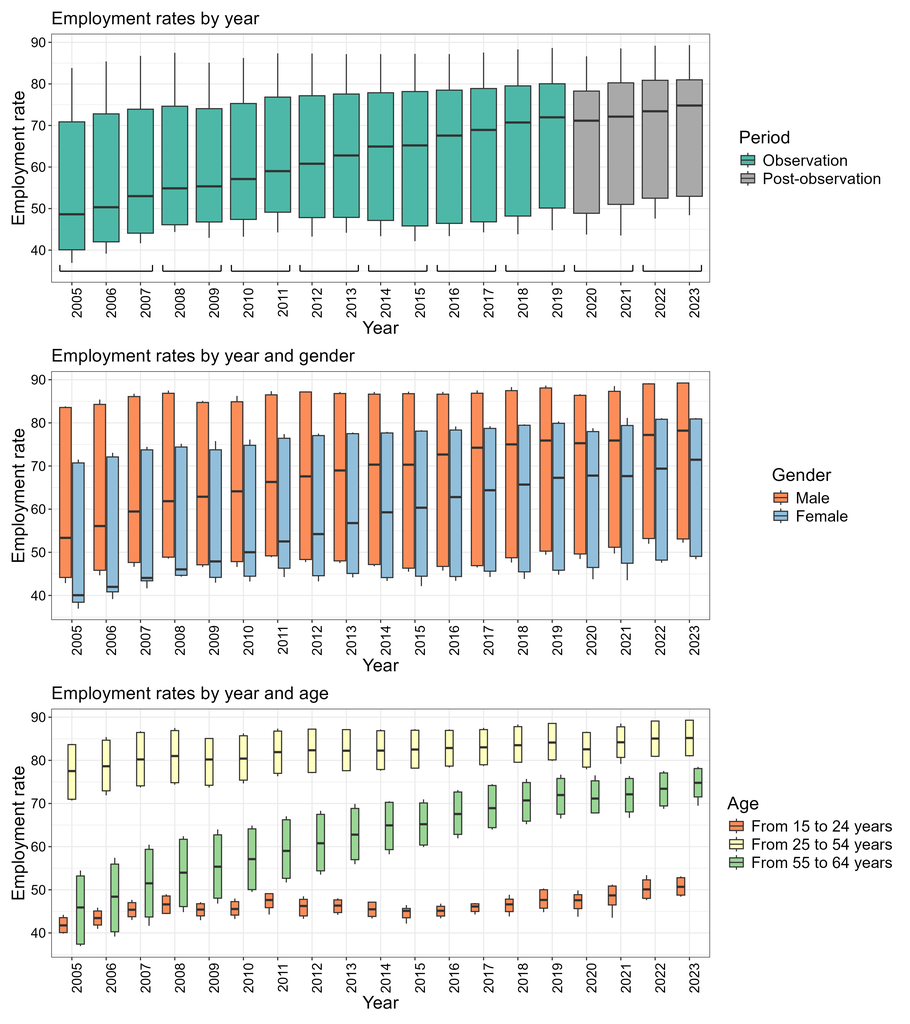

Employment rates in Germany separated by year. The figure displays the employment rates overall and separately by gender and age group. Because the employment rate is available quarterly, the upper boxplots represent 24 observations ($4 \times 2 \times 3$), the middle boxplots represent 12 observations ($4 \times 3$), and the lower boxplots represent 8 observations ($4 \times 2$). The square brackets in the upper panel indicate the different seasons.

Load and inspect preprocessed real-world data: quarterly employment rates in Germany, broken down by gender and age group, from 2005 to 2023:

```r
load("dataconcdrift.Rda")

# Display the first few rows of the dataset
head(dataconcdrift)
```

```
     empl_rate Year Gender_male Age_25_54 Age_55_64
20    53.05928 2005           1         0         1
98    39.85278 2005           0         0         0
674   83.54943 2005           1         1         0
771   36.93543 2005           0         0         1
1599  70.69067 2005           0         1         0
3222  42.85907 2005           1         0         0
```

Store the year information separately and remove it from the data:

```r
years <- dataconcdrift$Year
dataconcdrift$Year <- NULL

# Note:
# The data is segmented into "seasons" of two consecutive years each.
# The first season is an exception and spans three years (2005–2007).
```

Initialize the regression task and configure mlr3-specific components:

```r
# Set seed for reproducibility
set.seed(1234)

# Load required packages:
library("mlr3")
library("mlr3verse")

# Suppress unnecessary log messages from mlr3
lgr::get_logger("mlr3")$set_threshold("warn")

# Define the regression learners:
learner_temp_rf <- lrn("regr.ranger")  # Random forest
learner_temp_lm <- lrn("regr.lm")      # Linear regression

# Define the regression task:
task <- as_task_regr(dataconcdrift, target = "empl_rate")
```

Standard repeated CV (**not** recommended; 7 folds x 10 repeats):

```r
# Create a repeated CV object
cv <- rsmp("repeated_cv", repeats = 10, folds = 7)

# Instantiate the CV splits on the current task
cv$instantiate(task)

# CV for random forests
result_cv <- resample(task = task, learner = learner_temp_rf, resampling = cv)
mse_cv_rf <- result_cv$aggregate(msr("regr.mse"))

# CV for linear model
result_cv <- resample(task = task, learner = learner_temp_lm, resampling = cv)
mse_cv_lm <- result_cv$aggregate(msr("regr.mse"))
```

Out-of-sample validation (**recommended!**) without buffer: Train on first 8 seasons (2005–2021), test on last season (2022–2023):

```r
# Train the random forest on years 2005 to 2021 (i.e., seasons 1 to 8)
learner_temp_rf$train(task, row_ids = which(years %in% 2005:2021))

# Predict employment rates for the final season (2022–2023)
predictions <- learner_temp_rf$predict(task, row_ids = which(years %in% 2022:2023))

# Compute the MSE
mse_TSholdout_1s_rf <- predictions$score(msr("regr.mse"))

# Repeat the same for the linear model:
learner_temp_lm$train(task, row_ids = which(years %in% 2005:2021))
predictions <- learner_temp_lm$predict(task, row_ids = which(years %in% 2022:2023))
mse_TSholdout_1s_lm <- predictions$score(msr("regr.mse"))
```

Out-of-sample validation (**recommended!**) with buffer: Train on first 7 seasons (2005–2019), test on last season (2022–2023):

```r
# Train the random forest on years 2005 to 2019 (seasons 1 to 7)
learner_temp_rf$train(task, row_ids = which(years %in% 2005:2019))

# Predict on the final season (2022–2023), skipping 2020–2021
predictions <- learner_temp_rf$predict(task, row_ids = which(years %in% 2022:2023))

# Compute the MSE
mse_TSholdout_2s_rf <- predictions$score(msr("regr.mse"))

# Repeat for the linear model:
learner_temp_lm$train(task, row_ids = which(years %in% 2005:2019))
predictions <- learner_temp_lm$predict(task, row_ids = which(years %in% 2022:2023))
mse_TSholdout_2s_lm <- predictions$score(msr("regr.mse"))
```

Print MSEs of all variants for comparison:

```r
# Random forests: CV and out-of-sample validation without and with buffer
mse_cv_rf           # MSE with standard CV
```

```
regr.mse
76.79756
```

```r
mse_TSholdout_1s_rf # MSE with out-of-sample validation without buffer
```

```
regr.mse
113.7258
```

```r
mse_TSholdout_2s_rf # MSE with out-of-sample validation with buffer
```

```
regr.mse
 118.665
```

```r
# Linear models: CV and out-of-sample validation without and with buffer
mse_cv_lm           # MSE with standard CV
```

```
regr.mse
32.85211
```

```r
mse_TSholdout_1s_lm # MSE with out-of-sample validation without buffer
```

```
regr.mse
63.97613
```

```r
mse_TSholdout_2s_lm # MSE with out-of-sample validation with buffer
```

```
regr.mse
77.23427
```

## Hierarchically Structured Outcomes

Load a simulated dataset with a hierarchically structured outcome:

```r
# Load the dataset (assumed to include a hierarchical class structure in 'y')
load("datahier.Rda")

# Display the first few rows of the dataset
head(datahier)
```

```
          X1          X2         X3          X4         X5            y
1  1.6560430  0.01944618 -0.1784938  0.61826066 -0.5888845 3.8.17.38.86
2  1.8098054  0.11052882 -0.6545246  2.04793696 -0.5571252 3.8.17.38.86
3 -1.1750368  1.15657044  1.5761573 -1.15562484  1.0477405 2.4.10.21.46
4 -0.3667033 -0.54222046 -0.7014037  1.35294141  1.0560286 3.8.17.38.86
5  0.3536254 -1.24920128  0.2428764 -0.36752198  0.2996132 2.5.12.27.61
6  0.3191562 -1.28001260  0.5160358 -0.05831046 -0.3851475 2.5.12.27.60
```

Load the required packages:

```r
library("mlr3")       # Core mlr3 functionality
library("hierclass")  # Provides top-down hierarchical classifier and hierarchy-aware measures
```

The package `hierclass` loaded above is not available on CRAN but can be installed directly from GitHub via the repository https://github.com/RomanHornung/hierclass. To install it, use the following command:

```r
remotes::install_github("RomanHornung/hierclass")
```

The `hierclass` package implements top-down hierarchical classification using random forests as local classifiers. This functionality is provided as an `mlr3` learner, allowing easy integration into `mlr3` workflows. In addition, the package offers a set of hierarchical performance measures—hierarchical F-score, hierarchical precision, hierarchical recall, (weighted) shortest path distance, and H-loss—which are available as `mlr3` measures.

```r
# Suppress mlr3 logging output for cleaner console output
lgr::get_logger("mlr3")$set_threshold("warn")

# Create a classification task with target 'y' and all remaining columns as features
task <- as_task_classif(y ~ ., data = datahier)

# This learner performs classification exploiting the class hierarchy,
# using random forests for node-level decisions
learner <- lrn("classif.topdown")
```

Standard repeated CV (**not** recommended; 5 folds x 2 repeats):

```r
# Set seed for reproducibility
set.seed(1234)

# Create a repeated CV object: 2 repeats of 5-fold CV
cv <- rsmp("repeated_cv", repeats = 2, folds = 5)

# Instantiate the CV splits on the current task
cv$instantiate(task)

# Run the CV for the top-down classifier
result_cv <- resample(task = task, learner = learner, resampling = cv)

# Aggregate performance across folds using a variety of hierarchical and flat measures:
CV_vals <- c(
  result_cv$aggregate(msr("classif.hierfbeta", type = "micro")),  # Hierarchical F-score (micro-averaged)
  result_cv$aggregate(msr("classif.hierpr", type = "micro")),     # Hierarchical precision (micro)
  result_cv$aggregate(msr("classif.hierre", type = "micro")),     # Hierarchical recall (micro)
  result_cv$aggregate(msr("classif.hloss")),                      # H-loss (hierarchical loss)
  result_cv$aggregate(msr("classif.spath")),                      # (Weighted) shortest path distance
  result_cv$aggregate(msr("classif.acc"))                         # Standard (flat) accuracy
)
```

Stratified repeated CV, using target variable for stratification (**recommended!**):

```r
# Use the same seed again
set.seed(1234)

# Use target variable for stratification
task$col_roles$stratum <- task$target_names

# Instantiate the CV splits after stratification
cv$instantiate(task)

# Run CV again, now stratified
result_cv <- resample(task = task, learner = learner, resampling = cv)

# Aggregate hierarchical and flat performance measures again
stratCV_vals <- c(
  result_cv$aggregate(msr("classif.hierfbeta", type = "micro")),
  result_cv$aggregate(msr("classif.hierpr", type = "micro")),
  result_cv$aggregate(msr("classif.hierre", type = "micro")),
  result_cv$aggregate(msr("classif.hloss")),
  result_cv$aggregate(msr("classif.spath")),
  result_cv$aggregate(msr("classif.acc"))
)
```

Summarize and compare the results:

```r
# Combine both sets of evaluation results into a data frame
metrics <- data.frame(
  measure = c("hierf_micro", "hierpr_micro", "hierre_micro", "hloss", "spath", "acc"),
  CV = CV_vals,
  strat_CV = stratCV_vals
)
rownames(metrics) <- NULL

# Print performance metrics for both CV strategies
metrics
```

```
       measure        CV  strat_CV
1  hierf_micro 0.5304000 0.5614331
2 hierpr_micro 0.5304000 0.5614331
3 hierre_micro 0.5304000 0.5614331
4        hloss 0.3494766 0.3286855
5        spath 1.7678086 1.6490525
6          acc 0.2780000 0.3114116
```

## Spatial Data

Here, we will use the `ecuador` dataset available in the R package `mlr3spatiotempcv`, which implements various spatial CV procedures, where many of them will be used in the below code. The dataset contains georeferenced points in southern Ecuador labeled by whether a rainfall-triggered shallow landslide occurred (`slides = TRUE/FALSE`). Each point includes terrain attributes such as elevation, slope, curvature, and catchment area, derived from high-resolution digital elevation models.

Load the required packages:

```r
library("mlr3")
library("mlr3learners")
library("mlr3spatiotempcv")
library("data.table")
library("sf")
```

For two of the resampling strategies, we generate artificial grouping variables. The “Single split into training and test data” approach requires a categorical variable (`train_test`) that separates the observation space into two regions—one used for training the model and the other for evaluating its predictive performance. The “Partitioning based on geographical units” approach needs a categorical variable (`location`) that assigns each observation to one of several distinct spatial areas (in our case, 8). We create these two variables by applying k-means clustering to the spatial coordinates: with `k = 2` to define `train_test`, and `k = 8` to define `location`. In real-world applications, however, these groupings would correspond to meaningful geographic units (e.g. administrative districts).

Prepare the data and create the variables `train_test` and `location`:

```r
ecuador2 <- ecuador

# Remove redundant covariate (log.carea contains the same information)
ecuador2$carea <- NULL

# Convert to sf object
ecuador2_sf <- st_as_sf(ecuador2, coords = c("x", "y"), crs = 32717)

# Add 'train_test' and 'location' to the data set:
coords <- st_coordinates(ecuador2_sf)
set.seed(1234)
clusters_2 <- kmeans(coords, centers = 2)$cluster
clusters_8 <- kmeans(coords, centers = 8)$cluster
ecuador2_sf$train_test <- factor(ifelse(clusters_2 == 1, "train", "test"))
ecuador2_sf$location <- factor(clusters_8)

# Display the first few rows of the dataset
head(ecuador2_sf)
```

```
Simple feature collection with 6 features and 12 fields
Geometry type: POINT
Dimension:     XY
Bounding box:  xmin: 712802.5 ymin: 9559312 xmax: 715392.5 ymax: 9560172
Projected CRS: WGS 84 / UTM zone 17S
      dem    slope    hcurv    vcurv   cslope distroad slides distdeforest
1 1911.52 25.56423 -0.00681 -0.00029 34.42789      300   TRUE        15.00
2 2198.66 23.24719 -0.00501 -0.00649 30.71569      300   TRUE       300.00
3 1988.71 40.47660 -0.01919 -0.04051 32.81444      300   TRUE       300.00
4 2320.49 42.85782 -0.01106 -0.04634 33.90592      300   TRUE       300.00
5 2021.07 41.97661  0.00958  0.02642 41.60017      300   TRUE       300.00
6 1838.40 52.10134  0.00183 -0.09203 30.29457      300   TRUE         9.15
  distslidespast log.carea                 geometry train_test location
1              9  3.746431 POINT (712882.5 9560003)       test        2
2             21  3.145890 POINT (715232.5 9559583)      train        1
3             40  5.545499 POINT (715392.5 9560173)       test        1
4            100  2.699406 POINT (715042.5 9559313)      train        1
5             21  2.826839 POINT (715382.5 9560143)       test        1
6              2  2.802317 POINT (712802.5 9559953)       test        2
```

Configure spatial elements and mlr3-specific components, and initialize the spatial classification task:

```r
# Set seed for reproducibility:
set.seed(1234)

# Remove train_test and location from covariates for modeling
ecuador_model_data <- st_drop_geometry(ecuador2_sf)
ecuador_model_data$train_test <- NULL
ecuador_model_data$location <- NULL

# Suppress logging output from mlr3
lgr::get_logger("mlr3")$set_threshold("warn")

# Combine modeling data and geometry into a new sf object
ecuador_model_sf <- st_sf(ecuador_model_data, geometry = st_geometry(ecuador2_sf))

# Then create the task from this sf object
task <- as_task_classif_st(
  ecuador_model_sf,
  target = "slides",
  positive = "TRUE",
  id = "ecuador_custom"
)

# Define learner (logistic regression) and measure (area under the ROC curve)
learner <- lrn("classif.log_reg", predict_type = "prob")
measure <- msr("classif.auc")
```

Make a container in which the results will stored:

```r
results <- data.table(method = character(), score = numeric())
```

### (1) Single Split into Training and Test Data

In this most basic approach, we divide the dataset once into two regions, one used for training the model and the other for evaluating its predictive performance. This is, for example, useful when one wants to evaluate model performance on a spatially distinct area, such as a newly surveyed region. In the below code, the variable `train_test`, created earlier, indicates which observations belong to the training and test region.

```r
train_idx <- which(ecuador2_sf$train_test == "train")
test_idx  <- which(ecuador2_sf$train_test == "test")
resampling_holdout <- rsmp("custom")
resampling_holdout$instantiate(task, train_sets = list(train_idx), test_sets = list(test_idx))
rr1 <- resample(task, learner, resampling_holdout)

results <- rbind(results, data.table(method = "train_test_split", score = rr1$aggregate(measure)))
```

### (2) Rectangular Tiles Corresponding to Folds (“Leave-One-Block-Out CV”)

This resampling approach divides the spatial domain into rectangular tiles using a fixed spatial resolution (set via `dsplit` or `nsplit`). Each tile is used once as a test set.

```r
rs2 <- rsmp("spcv_tiles", dsplit = c(1500L, 1500L))  # each tile ~1500x1500 meters
rs2$instantiate(task)
rr2 <- resample(task, learner, rs2)

results <- rbind(results, data.table(method = "tiles_fixed", score = rr2$aggregate(measure)))
```

### (3) Rectangular Tiles Randomly Assigned to Folds

In this approach, the spatial domain is again divided into a regular grid, but the resulting tiles are randomly assigned to folds.

```r
rs3 <- rsmp("spcv_block", rows = 5, cols = 5, folds = 10)
rs3$instantiate(task)
rr3 <- resample(task, learner, rs3)

results <- rbind(results, data.table(method = "tiles_random", score = rr3$aggregate(measure)))
```

### (4) K-means Clustering in Coordinate Space

Here, folds are defined via k-means clustering on the spatial coordinates. This creates spatially compact, data-driven groupings that are not tied to a fixed grid.

```r
rs4 <- rsmp("spcv_coords", folds = 5)
rs4$instantiate(task)
rr4 <- resample(task, learner, rs4)

results <- rbind(results, data.table(method = "clustering_coordinates", score = rr4$aggregate(measure)))
```

### (5) K-means Clustering in Covariate Space

Instead of using spatial coordinates, this method uses all numerical covariates to define the folds via k-means clustering. It aims to evaluate generalization to new (e.g. environmental or terrain) conditions.

```r
rs5 <- rsmp("spcv_env", folds = 5)
rs5$instantiate(task)
rr5 <- resample(task, learner, rs5)

results <- rbind(results, data.table(method = "clustering_covariates", score = rr5$aggregate(measure)))
```

### (6) Leave-One-Disc-Out CV Without Buffer

This method repeatedly withholds a randomly located disc-shaped region of a certain radius for testing. The remaining points form the training set.

```r
rs6 <- rsmp("spcv_disc", radius = 1000, buffer = 0, folds = 100)
rs6$instantiate(task)
rr6 <- resample(task, learner, rs6)

results <- rbind(results, data.table(method = "leave_disc", score = rr6$aggregate(measure)))
```

### (7) Leave-One-Disc-Out CV With Buffer

This variation adds a buffer zone of a certain width around each disc. Buffer zones should only be employed when predictions are intended for new areas, where the distance to these areas exceeds the distances between neighboring observations in the training data.

```r
rs7 <- rsmp("spcv_disc", radius = 800, buffer = 200, folds = 100)
rs7$instantiate(task)
rr7 <- resample(task, learner, rs7)

results <- rbind(results, data.table(method = "leave_disc_buffer", score = rr7$aggregate(measure)))
```

### (8) Partitioning Based on Geographical Units

This method can be used in situations where observations are grouped into predefined spatial units (e.g., administrative regions). In each iteration, one spatial unit is used for testing, and the rest for training. In the below code, the variable `location`, created earlier, defines these groups.

```r
# IMPORTANT: The variable 'location' must not be included as a covariate in the task
# ('location' was already removed before the task was created above).
# In this resampling strategy, each fold corresponds to one unique value of 'location'.
# Therefore, during training, the model will *not* see the level of 'location' that appear
# in the test fold.
# If 'location' were included as a covariate (i.e., a factor), this would cause a failure
# at prediction time, since the model cannot handle previously unseen factor levels.

rs8 <- rsmp("custom_cv")
rs8$instantiate(task, f = ecuador2_sf$location)
rr8 <- resample(task, learner, rs8)

results <- rbind(results, data.table(method = "geo_units", score = rr8$aggregate(measure)))
```

### Final Comparison of Results

```r
print(results)
```

```
                   method     score
                   <char>     <num>
1:       train_test_split 0.7396649
2:            tiles_fixed 0.7019522
3:           tiles_random 0.6782299
4: clustering_coordinates 0.6756959
5:  clustering_covariates 0.7019607
6:             leave_disc 0.6736209
7:      leave_disc_buffer 0.6832985
8:              geo_units 0.6765898
```